# Creating Publication-Quality Graphics with ggplot2

#### Challenge 1

Modify the example so that the figure shows how life expectancy has changed over time:

```r
ggplot(data = gapminder, mapping = aes(x = gdpPercap, y = lifeExp)) + geom_point()
```

Hint: the gapminder dataset has a column called “year”, which should appear on the x-axis.

Click to show the solution

#### Solution to Challenge 1:

Here is one possible solution:

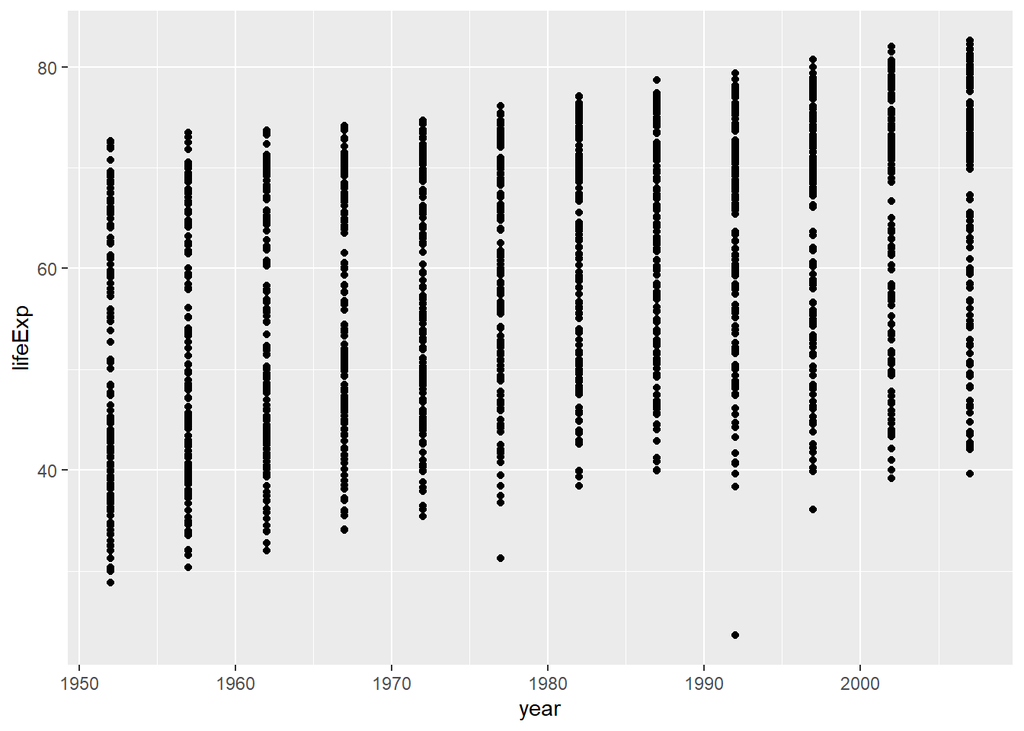

Binned scatterplot of life expectancy versus year showing how life expectancy has increased over time

```r
ggplot(data = gapminder, mapping = aes(x = year, y = lifeExp)) + geom_point()
```

#### Challenge 2

In the previous examples and challenge we’ve used the `aes` function to tell the scatterplot **geom** about the **x** and **y** locations of each point. Another *aesthetic* property we can modify is the point *color*. Modify the code from the previous challenge to **color** the points by the “continent” column. What trends do you see in the data? Are they what you expected?

Click to show the solution

#### Solution to Challenge 2:

The solution presented below adds `color=continent` to the call of the `aes` function. The general trend seems to indicate an increased life expectancy over the years. On continents with stronger economies we find a longer life expectancy.

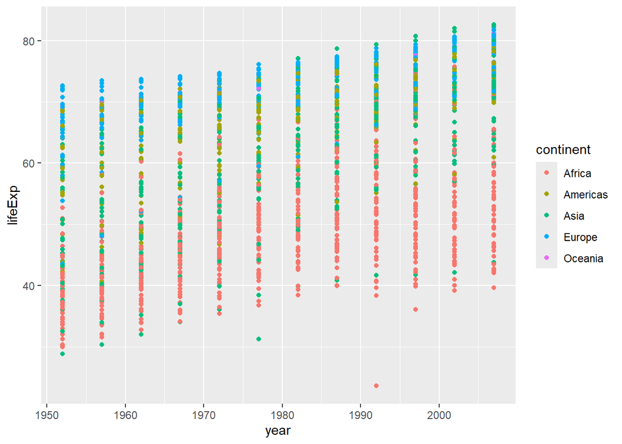

Binned scatterplot of life expectancy vs year with color-coded continents showing value of ‘aes’ function

```r
ggplot(data = gapminder, mapping = aes(x = year, y = lifeExp, color=continent)) +
  geom_point()
```

## Layers

Using a scatterplot probably isn’t the best for visualizing change over time. Instead, let’s tell `ggplot` to visualize the data as a line plot:

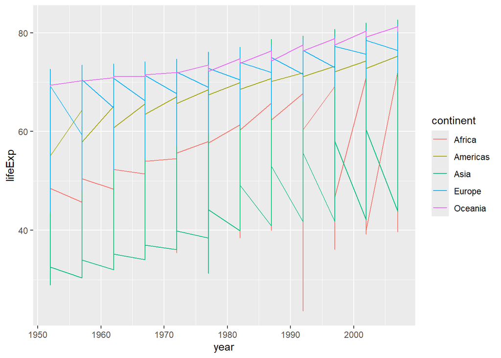

```r
ggplot(data = gapminder, mapping = aes(x=year, y=lifeExp, color=continent)) +
  geom_line()
```

Instead of adding a `geom_point` layer, we’ve added a `geom_line` layer.

However, the result doesn’t look quite as we might have expected: it seems to be jumping around a lot in each continent. It appears to be drawing one line per continent, but each continent contains many countries!

Let’s try to separate the data by country, plotting one line for each country:

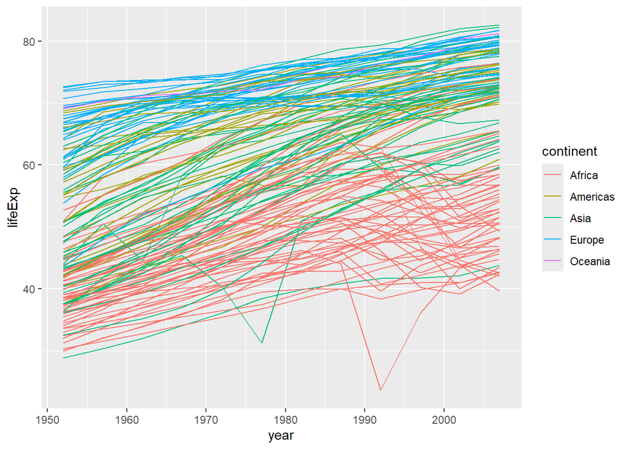

```r
ggplot(data = gapminder, mapping = aes(x=year, y=lifeExp, group=country, color=continent)) +
  geom_line()
```

We’ve added the **group** *aesthetic*, which tells `ggplot` to draw a line for each country.

But what if we want to visualize both lines and points on the plot? We can add another layer to the plot:

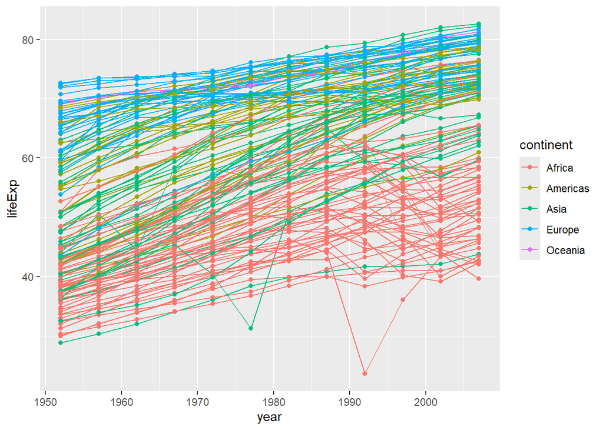

```r
ggplot(data = gapminder, mapping = aes(x=year, y=lifeExp, group=country, color=continent)) +
  geom_line() + geom_point()
```

It’s important to note that each layer is drawn on top of the previous layer. In this example, the points have been drawn *on top of* the lines. Here’s a demonstration:

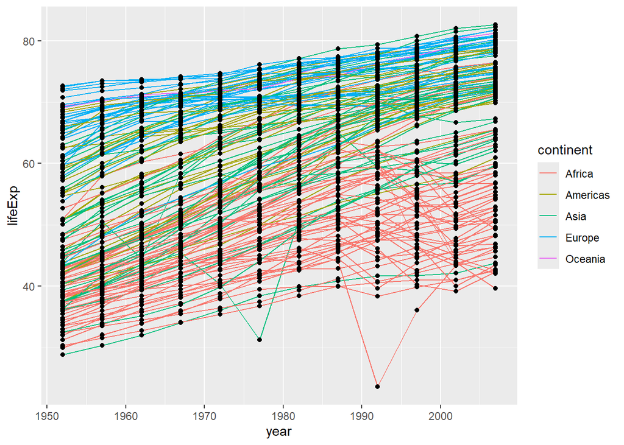

```r
ggplot(data = gapminder, mapping = aes(x=year, y=lifeExp, group=country)) +
  geom_line(mapping = aes(color=continent)) + geom_point()
```

In this example, the *aesthetic* mapping of **color** has been moved from the global plot options in `ggplot` to the `geom_line` layer so it no longer applies to the points. Now we can clearly see that the points are drawn on top of the lines.

Look carefully at the code above; the `color=continent` command is placed within the `geom_line()` command, not the `mapping` command.

#### Tip: Setting an aesthetic to a value instead of a mapping

So far, we’ve seen how to use an aesthetic (such as **color**) as a *mapping* to a variable in the data. For example, when we use `geom_line(mapping = aes(color=continent))`, ggplot will give a different color to each continent. But what if we want to change the color of all lines to blue? You may think that `geom_line(mapping = aes(color="blue"))` should work, but it doesn’t. Since we don’t want to create a mapping to a specific variable, we can move the color specification outside of the `aes()` function, like this: `geom_line(color="blue")`.

#### Challenge 3

Switch the order of the point and line layers from the previous example. What happened?

Click to show the solution

#### Solution to challenge 3:

The lines now get drawn over the points!

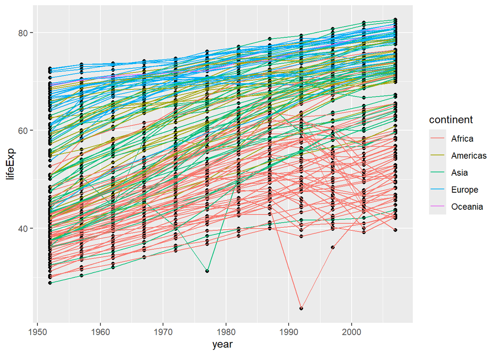

```r
ggplot(data = gapminder, mapping = aes(x=year, y=lifeExp, group=country)) +
 geom_point() + geom_line(mapping = aes(color=continent))
```

## Transformations and statistics

ggplot2 also makes it easy to overlay statistical models over the data. To demonstrate we’ll go back to our first example:

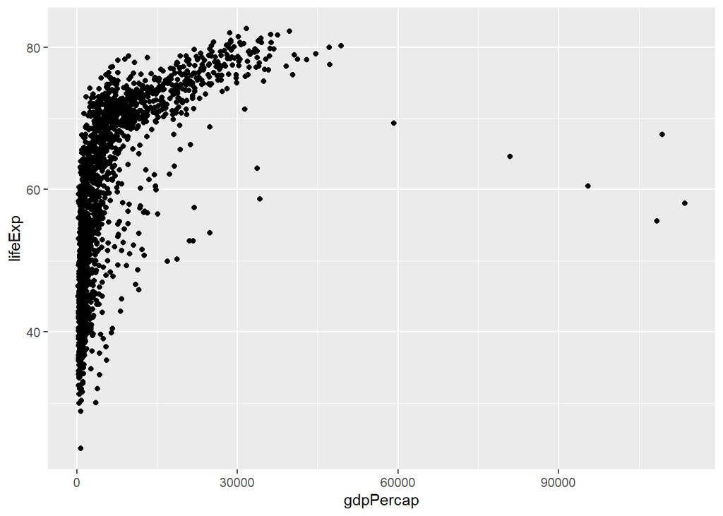

```r
ggplot(data = gapminder, mapping = aes(x = gdpPercap, y = lifeExp)) +
  geom_point()
```

Currently it’s hard to see the relationship between the points due to some strong outliers in GDP per capita. We can change the scale of units on the x axis using the *scale* functions. These control the mapping between the data values and visual values of an aesthetic. We can also modify the transparency of the points, using the *alpha* function, which is especially helpful when you have a large amount of data which is very clustered.

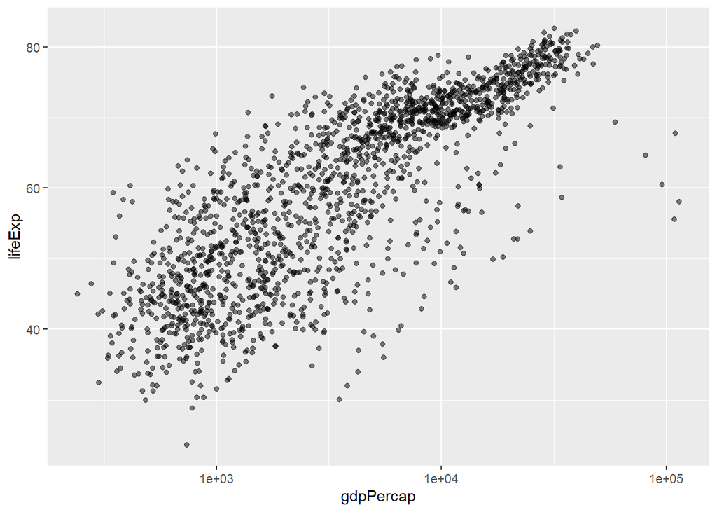

Scatterplot of GDP vs life expectancy showing logarithmic x-axis data spread

```r
ggplot(data = gapminder, mapping = aes(x = gdpPercap, y = lifeExp)) +
  geom_point(alpha = 0.5) + scale_x_log10()
```

The `scale_x_log10` function applied a transformation to the coordinate system of the plot, so that each multiple of 10 is evenly spaced from left to right. For example, a GDP per capita of 1,000 is the same horizontal distance away from a value of 10,000 as the 10,000 value is from 100,000. This helps to visualize the spread of the data along the x-axis.

#### Tip Reminder: Setting an aesthetic to a value instead of a mapping

Notice that we used `geom_point(alpha = 0.5)`. As the previous tip mentioned, using a setting outside of the `aes()` function will cause this value to be used for all points, which is what we want in this case. But just like any other aesthetic setting, *alpha* can also be mapped to a variable in the data. For example, we can give a different transparency to each continent with `geom_point(mapping = aes(alpha = continent))`.

We can fit a simple relationship to the data by adding another layer, `geom_smooth`:

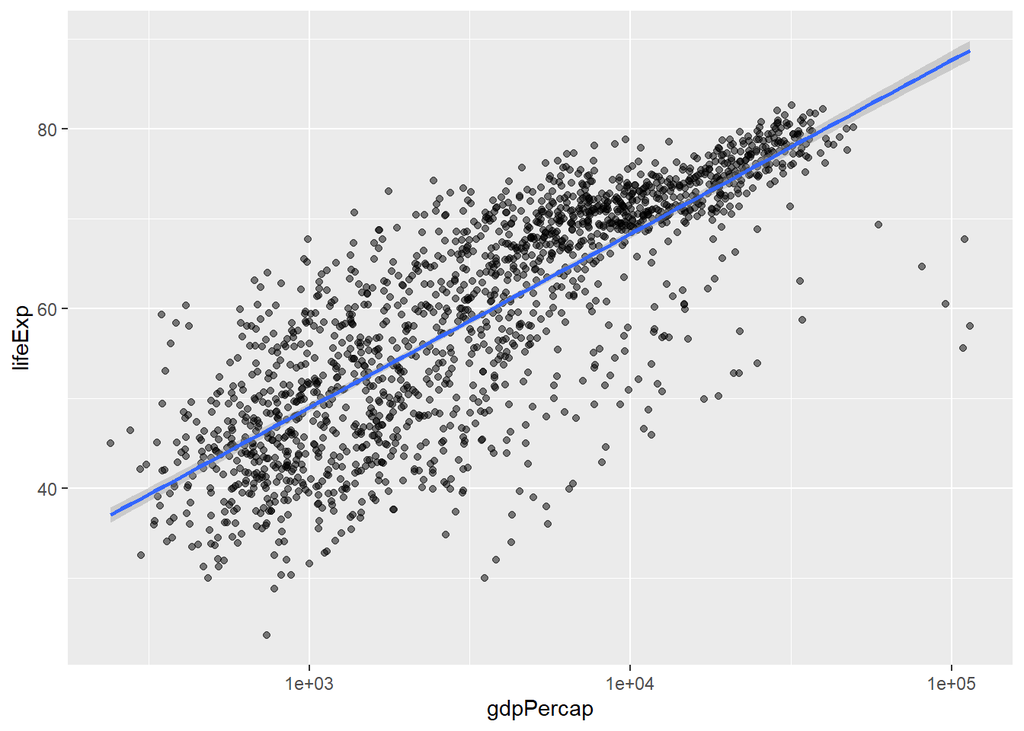

```r
ggplot(data = gapminder, mapping = aes(x = gdpPercap, y = lifeExp)) +
  geom_point(alpha = 0.5) + scale_x_log10() + geom_smooth(method="lm")
```

We can make the line thicker by *setting* the **linewidth** aesthetic in the `geom_smooth` layer:

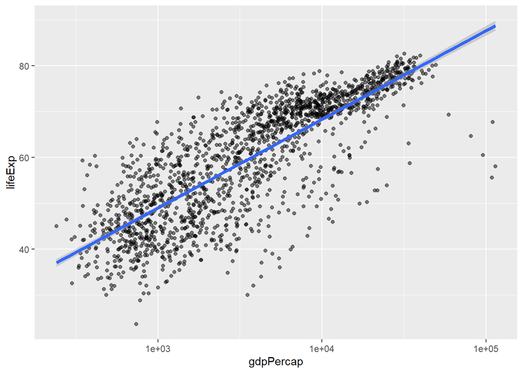

```r
ggplot(data = gapminder, mapping = aes(x = gdpPercap, y = lifeExp)) +
  geom_point(alpha = 0.5) + scale_x_log10() + geom_smooth(method="lm", linewidth=1.5)
```

There are two ways an *aesthetic* can be specified. Here we *set* the **linewidth** aesthetic by passing it as an argument to `geom_smooth` and it is applied the same to the whole `geom`. Previously in the lesson we’ve used the `aes` function to define a *mapping* between data variables and their visual representation.

#### Challenge 4a

Modify the color and size of the points on the point layer in the previous example.

Hint: do not use the `aes` function.

Hint: the equivalent of `linewidth` for points is `size`.

Click to show the solution

#### Solution to challenge 4a:

Here a possible solution: Notice that the `color` argument is supplied outside of the `aes()` function. This means that it applies to all data points on the graph and is not related to a specific variable.

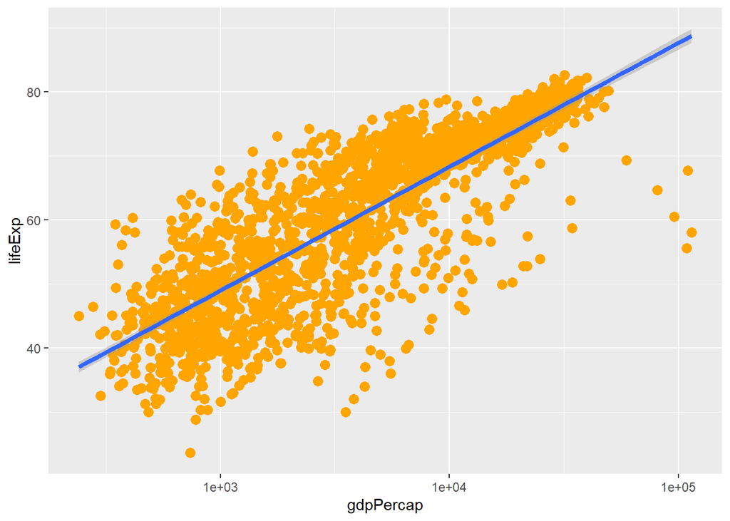

```r
ggplot(data = gapminder, mapping = aes(x = gdpPercap, y = lifeExp)) +
 geom_point(size=3, color="orange") + scale_x_log10() +
 geom_smooth(method="lm", linewidth=1.5)
```

#### Challenge 4b

Modify your solution to Challenge 4a so that the points are now a different shape and are colored by continent with new trendlines. Hint: The color argument can be used inside the aesthetic.

Click to show the solution

#### Solution to challenge 4b:

Here is a possible solution: Notice that supplying the `color` argument inside the `aes()` functions enables you to connect it to a certain variable. The `shape` argument, as you can see, modifies all data points the same way (it is outside the `aes()` call) while the `color` argument which is placed inside the `aes()` call modifies a point’s color based on its continent value.

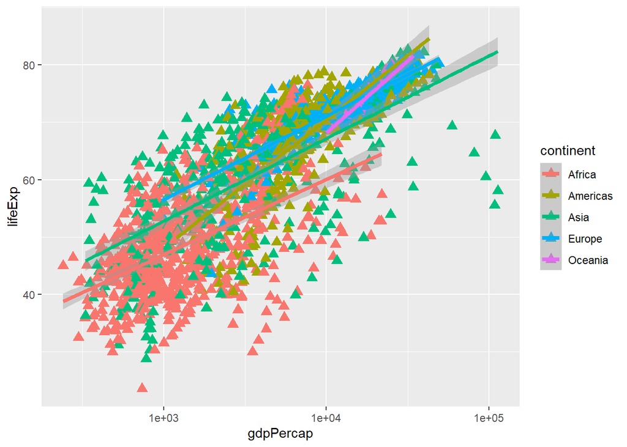

```r
ggplot(data = gapminder, mapping = aes(x = gdpPercap, y = lifeExp, color = continent)) +
 geom_point(size=3, shape=17) + scale_x_log10() +
 geom_smooth(method="lm", linewidth=1.5)
```

## Multi-panel figures

Earlier we visualized the change in life expectancy over time across all countries in one plot. Alternatively, we can split this out over multiple panels by adding a layer of **facet** panels.

#### Tip

We start by making a subset of data including only countries located in the Americas. This includes 25 countries, which will begin to clutter the figure. Note that we apply a “theme” definition to rotate the x-axis labels to maintain readability. Nearly everything in ggplot2 is customizable.

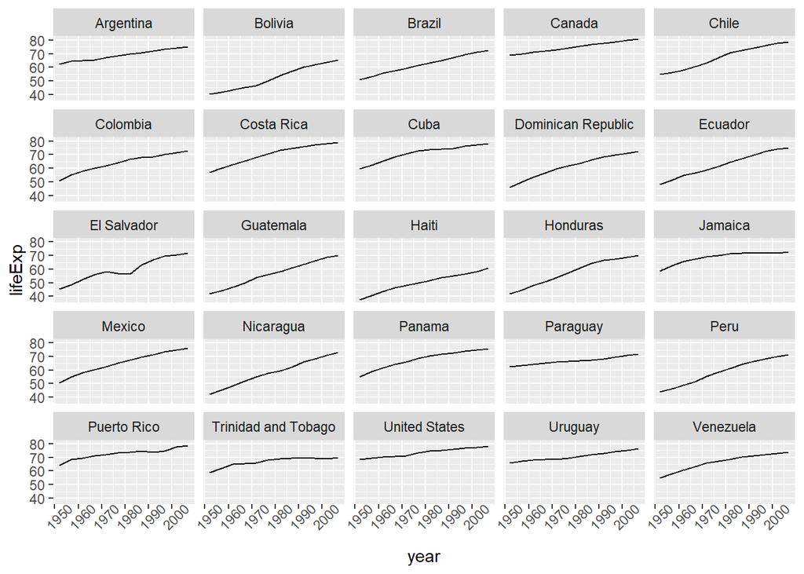

```r
americas <- gapminder[gapminder$continent == "Americas",]
ggplot(data = americas, mapping = aes(x = year, y = lifeExp)) +
  geom_line() +
  facet_wrap( ~ country) +
  theme(axis.text.x = element_text(angle = 45))
```

The `facet_wrap` layer took a “formula” as its argument, denoted by the tilde (~). This tells R to draw a panel for each unique value in the country column of the gapminder dataset.

## Modifying text

To clean this figure up for a publication we need to change some of the text elements. The x-axis is too cluttered, and the y axis should read “Life expectancy”, rather than the column name in the data frame.

We can do this by adding a couple of different layers. The **theme** layer controls the axis text, and overall text size. Labels for the axes, plot title and any legend can be set using the `labs` function.

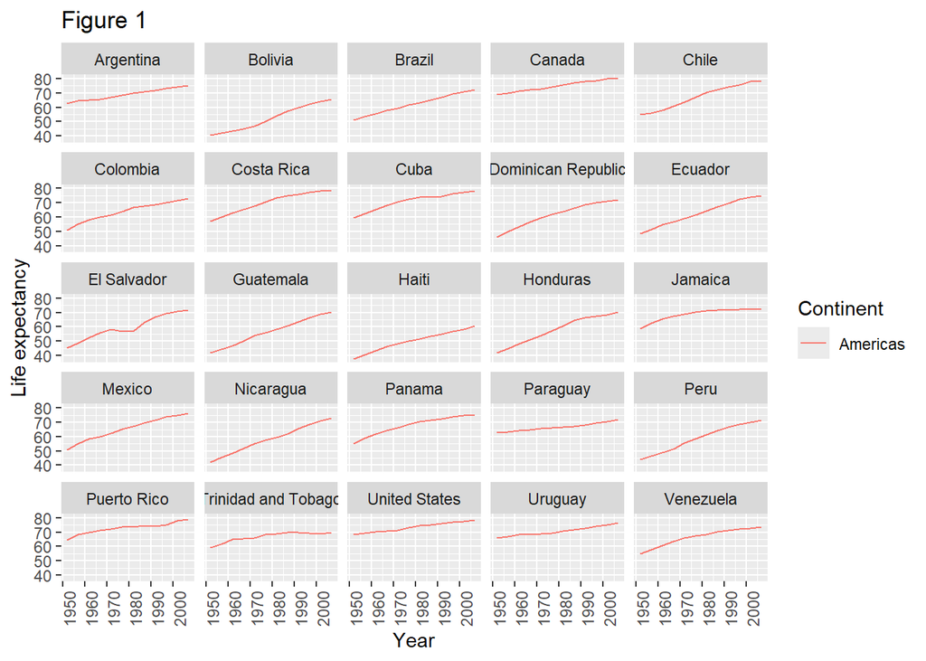

```r
ggplot(data = americas, mapping = aes(x = year, y = lifeExp, color=continent)) +
  geom_line() + facet_wrap( ~ country) +
  labs(
    x = "Year",              # x axis title
    y = "Life expectancy",   # y axis title
    title = "Figure 1",      # main title of figure
    color = "Continent"      # title of legend
  ) +
  theme(axis.text.x = element_text(angle = 90, hjust = 1))
```

## Exporting the plot

The `ggsave()` function allows you to export a plot created with ggplot. You can specify the dimension and resolution of your plot by adjusting the appropriate arguments (`width`, `height` and `dpi`) to create high quality graphics for publication. In order to save the plot from above, we first assign it to a variable `lifeExp_plot`, then tell `ggsave` to save that plot in `png` format to a directory called `results`. (Make sure you have a `results/` folder in your working directory.)

```r
lifeExp_plot <- ggplot(data = americas, mapping = aes(x = year, y = lifeExp, color=continent)) +
  geom_line() + facet_wrap( ~ country) +
  labs(
    x = "Year",              # x axis title
    y = "Life expectancy",   # y axis title
    title = "Figure 1",      # main title of figure
    color = "Continent"      # title of legend
  ) +
  theme(axis.text.x = element_text(angle = 90, hjust = 1))

ggsave(filename = "results/lifeExp.png", plot = lifeExp_plot, width = 12, height = 10, dpi = 300, units = "cm")
```

There are two nice things about `ggsave`. First, it defaults to the last plot, so if you omit the `plot` argument it will automatically save the last plot you created with `ggplot`. Secondly, it tries to determine the format you want to save your plot in from the file extension you provide for the filename (for example `.png` or `.pdf`). If you need to, you can specify the format explicitly in the `device` argument.

This is a taste of what you can do with ggplot2. RStudio provides a really useful [cheat sheet](https://www.rstudio.org/links/data_visualization_cheat_sheet) of the different layers available, and more extensive documentation is available on the [ggplot2 website](https://ggplot2.tidyverse.org/reference/). All RStudio cheat sheets are available from the [RStudio website](https://www.rstudio.com/resources/cheatsheets/). Finally, if you have no idea how to change something, a quick Google search will usually send you to a relevant question and answer on Stack Overflow with reusable code to modify!

#### Challenge 5

Generate boxplots to compare life expectancy between the different continents during the available years.

Advanced:

- Rename y axis as Life Expectancy.
- Remove x axis labels.

Click to show the solution

#### Solution to challenge 5:

Here a possible solution: `xlab()` and `ylab()` set labels for the x and y axes, respectively The axis title, text and ticks are attributes of the theme and must be modified within a `theme()` call.

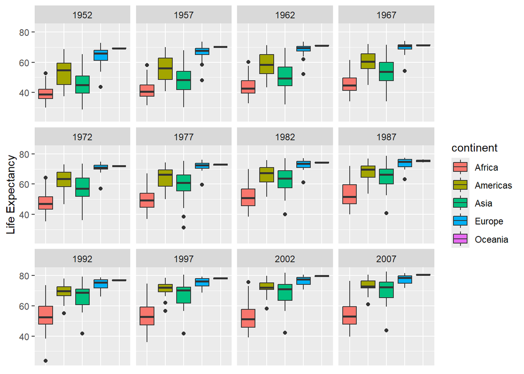

```r
ggplot(data = gapminder, mapping = aes(x = continent, y = lifeExp, fill = continent)) +
 geom_boxplot() + facet_wrap(~year) +
 ylab("Life Expectancy") +
 theme(axis.title.x=element_blank(),
       axis.text.x = element_blank(),
       axis.ticks.x = element_blank())
```

- Use `ggplot2` to create plots.
- Think about graphics in layers: aesthetics, geometry, statistics, scale transformation, and grouping.

# Bonus content: Reordering factor levels

As you have seen in the plots above, countries are ordered alphabetically. However, there are reasons that we might conceivably want to change this arrangement. What if for example, we wanted the data for countries from North America to be arranged at the top of this plot grid?

Here, we will convert country to a factor in the americas dataset and use `fct_relevel()` command to re-order them.

```r
americas$country.fac <- as.factor(americas$country)

levels(americas$country.fac)
```

```
##  [1] "Argentina"           "Bolivia"             "Brazil"
##  [4] "Canada"              "Chile"               "Colombia"
##  [7] "Costa Rica"          "Cuba"                "Dominican Republic"
## [10] "Ecuador"             "El Salvador"         "Guatemala"
## [13] "Haiti"               "Honduras"            "Jamaica"
## [16] "Mexico"              "Nicaragua"           "Panama"
## [19] "Paraguay"            "Peru"                "Puerto Rico"
## [22] "Trinidad and Tobago" "United States"       "Uruguay"
## [25] "Venezuela"
```

The following countries are in South America: Argentina, Bolivia, Brazil, Chile, Colombia, Ecuador, Paraguay, Peru, Uruguay, and Venezuela. We can also arrange Central American countries (Costa Rica, El Salvador, Guatemala, Honduras, Nicaragua, and Panama) in the middle.

We will use the `fct_relevel()` command from the forcats package (contained in the tidyverse) to do this

```r
americas$country.fac <- fct_relevel(americas$country.fac, "Canada", "Cuba", "Dominican Republic", "Haiti", "Jamaica", "Mexico",  "Puerto Rico", "Trinidad and Tobago", "United States","Costa Rica", "El Salvador", "Guatemala", "Honduras", "Nicaragua", "Panama", "Argentina", "Bolivia", "Brazil", "Chile", "Colombia", "Ecuador", "Paraguay", "Peru", "Uruguay", "Venezuela")

levels(americas$country.fac)
```

```
##  [1] "Canada"              "Cuba"                "Dominican Republic"
##  [4] "Haiti"               "Jamaica"             "Mexico"
##  [7] "Puerto Rico"         "Trinidad and Tobago" "United States"
## [10] "Costa Rica"          "El Salvador"         "Guatemala"
## [13] "Honduras"            "Nicaragua"           "Panama"
## [16] "Argentina"           "Bolivia"             "Brazil"
## [19] "Chile"               "Colombia"            "Ecuador"
## [22] "Paraguay"            "Peru"                "Uruguay"
## [25] "Venezuela"
```

Now we can specify that the `facet_wrap()` function should order things by this new division of countries into North and South America!

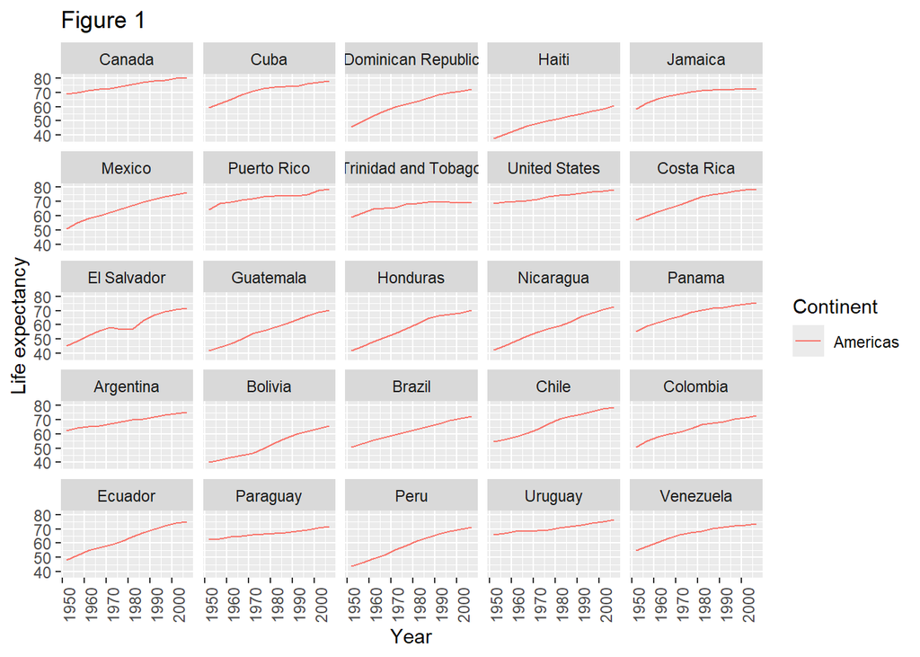

```r
ggplot(data = americas, mapping = aes(x = year, y = lifeExp, color=continent)) +
  geom_line() + facet_wrap( ~ country.fac) +
  labs(
    x = "Year",              # x axis title
    y = "Life expectancy",   # y axis title
    title = "Figure 1",      # main title of figure
    color = "Continent"      # title of legend
  ) +
  theme(axis.text.x = element_text(angle = 90, hjust = 1))
```